# STAT 311, HW4

Haochen Miao

Spring 2022

# Instructions

- This homework is due on Thursday 9 June 2022 by 11:59 pm. All late submissions are subject to the late submission policy described in the course syllabus.
- Please answer ALL questions (including those that do not involve R) in the locations marked in this template. Remember to periodically **knit** your document to check that the output appears as you want it to; you will be turning in your knit html document.
- You will need to upload your knitted html document in CANVAS. Please be sure to check that your file was uploaded correctly. It does not hurt to screenshot verification of the upload, because CANVAS can be glitchy on occasion.
- Please answer the questions in the order in which they are posed. Write in complete sentences, and support your answers where asked.

The following code chunk loads the same data set that you previously examined in quiz sections addressing the infectivity of the infectious hematopoietic necrosis virus (IHNV) on Chinook salmon (*Oncorhynchus tshawytscha*) from the Columbia River Basin (CRB) ([Hernandez et al. 2021](https://doi.org/10.3390/v13040701)).

```r
fishDat <- read.csv(
  file = "https://raw.githubusercontent.com/brownwuw/UW_STAT311_AU22/main/HernandezData.csv"
  )
```

To evaluate whether some Chinook populations are more susceptible to different strains of IHNV, fish from four CRB populations (Methow River, `mt`; North Santiam River, `ns`; Priest Rapids of the Hanford Reach, `pr`, and Cowlitz River, `cw`) were experimentally exposed to different strains (L, M, and U) and different doses of the virus (log10 doses: 2.3, 3.3, 4.3, and 5.3). Infection was assessed in two ways: `infection`: a binary indicator variable denoting whether each fish was infected following exposure (1) or not (0); and `log.viral.load`: quantifying the log10 amount of virus recovered from each fish after being euthanized (equaling `NA` if the fish had not been infected).

The following chunk creates box plots showing the distribution of log viral load stratified by fish population, strain, and exposure dose. Note that each plot is accompanied by a warning message indicating the number of fish who had `NA` for `log.viral.load` (229 out of 384 observations). The lost box plot also shows the overall distribution of log viral load, irrespective of experimental variables (fish population, viral strain, or exposure dose).

```
## Warning: Removed 229 rows containing non-finite values (stat_boxplot).
```

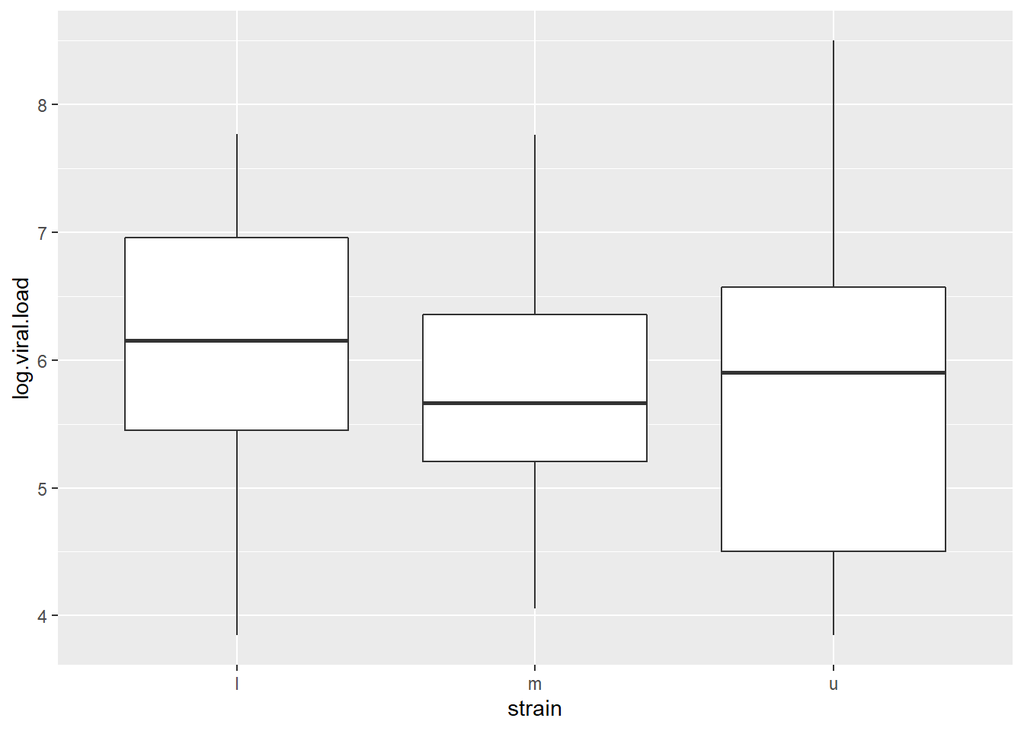

```r
fishDat %>% ggplot() +
  geom_boxplot(aes(x=strain, y=log.viral.load)) +
  ylim(
    min(fishDat$log.viral.load, na.rm=TRUE),
    max(fishDat$log.viral.load, na.rm=TRUE)
    )
```

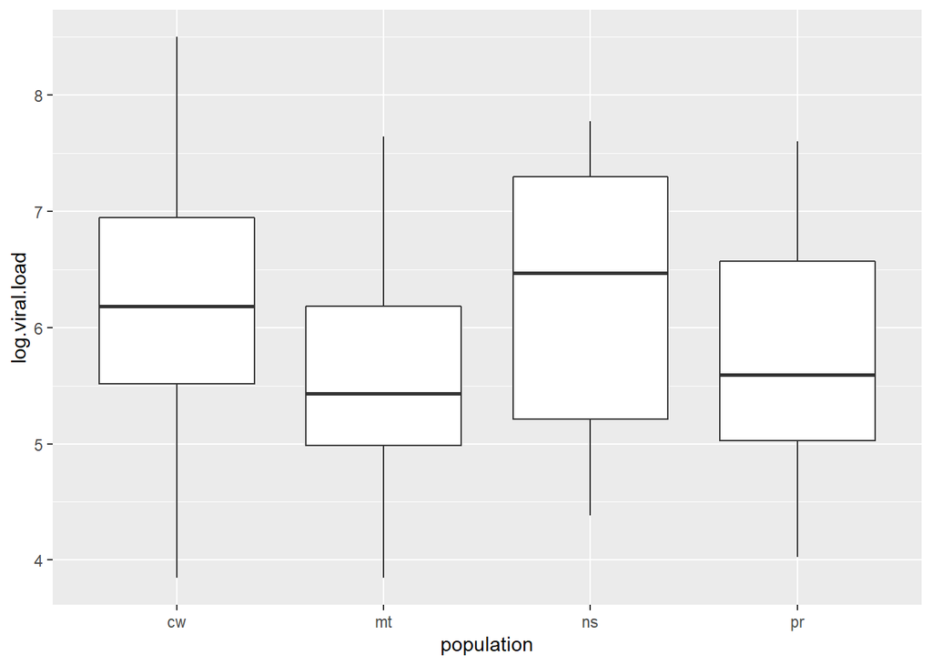

```r
fishDat %>% ggplot() +
  geom_boxplot(aes(x=population, y=log.viral.load)) +
  ylim(
    min(fishDat$log.viral.load, na.rm=TRUE),
    max(fishDat$log.viral.load, na.rm=TRUE)
    )
```

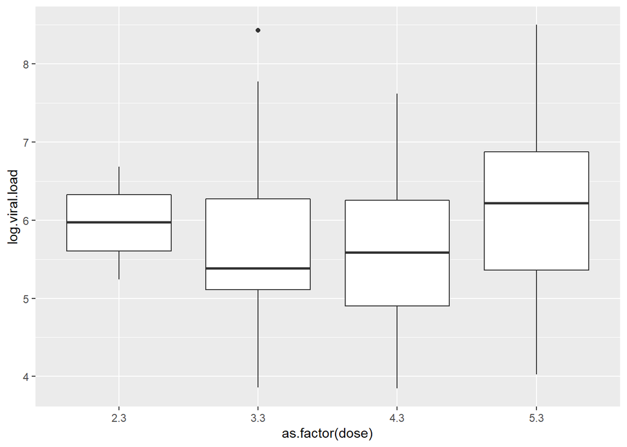

```r
fishDat %>% ggplot() +
  geom_boxplot(aes(x=as.factor(dose), y=log.viral.load)) +
  ylim(
    min(fishDat$log.viral.load, na.rm=TRUE),
    max(fishDat$log.viral.load, na.rm=TRUE)
    )
```

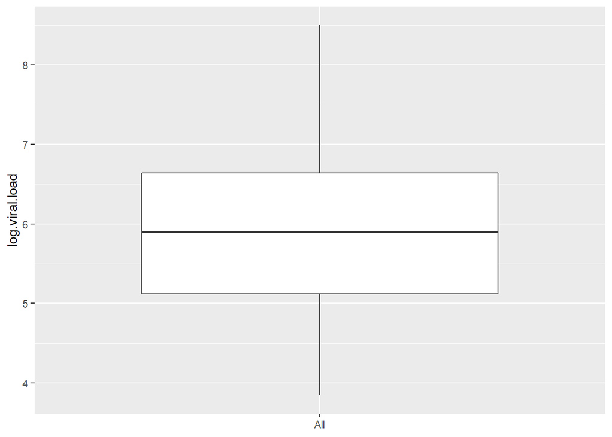

```r
fishDat %>% ggplot() +
  geom_boxplot(aes(x="All", y=log.viral.load)) +
  ylim(
    min(fishDat$log.viral.load, na.rm=TRUE),
    max(fishDat$log.viral.load, na.rm=TRUE)
    ) +
  theme(axis.title.x=element_blank())
```

For all analyses below, assume a level of significance $\alpha=0.05$.

# Excercise 1

```r
fishDat <- fishDat %>%
  mutate(endemic = ifelse(strain == "u" | strain == "l", 1, 0))

round(fishDat %>% select(infection, endemic) %>%
  table() %>% prop.table(margin = 2), 4)
```

```
##          endemic
## infection      0      1
##         0 0.5938 0.5977
##         1 0.4062 0.4023
```

The following chunk performs a test of independence between these two indicator variables based on their difference in sample proportions. The indicator `endemic` serves as the independent (or explanatory) variable, while `infection` is the dependent (or response) variable, so the parameter of interest $\pi$ is the probability of infection.
$$H_0:\pi_{endemic} =
\pi_{exotic}=p_{pooled}$$
which implies
$$H_0:\Delta\pi=0$$

```r
(p_pooled <- mean(fishDat$infection))
```

```
## [1] 0.4036458
```

```r
p_treatment <- fishDat %>% group_by(endemic) %>%
  summarize(
    p_treatment = mean(infection),
    n_treatment = n()
    )
p_treatment
```

```
## # A tibble: 2 x 3
##   endemic p_treatment n_treatment
##     <dbl>       <dbl>       <int>
## 1       0       0.406         128
## 2       1       0.402         256
```

```r
(Delta.p <- p_treatment$p_treatment[1] - p_treatment$p_treatment[2])
```

```
## [1] 0.00390625
```

```r
SE_Delta.p <- sqrt(
  sum(p_pooled*(1-p_pooled)/p_treatment$n_treatment)
  )
(z_obs <- Delta.p/SE_Delta.p)
```

```
## [1] 0.07354735
```

In this case, $z_{obs}\approx 0.0735$

in the following chunk, calculate the P-value for $z_{obs}$.

```r
z_test <- function(Delta.p, SE_Delta.p, tailed) {
  if(tailed == 1) return(cat('Z-Score - ', z_obs, '\np-value - ', pnorm(-abs(z_obs))))
  if(tailed == 2) return(cat('Z-Score -', z_obs, '\np_value -', 2 * pnorm(-abs(z_obs))))
  if(tailed != 1 | tailed != 2) return('can only be one or two tailed')
}

z_test_obs <- function (z_obs, tailed){
  if(tailed == 1) return(cat('Z-Score - ', z_obs, '\np-value - ', pnorm(-abs(z_obs))))
  if(tailed == 2) return(cat('Z-Score -', z_obs, '\np_value -', 2 * pnorm(-abs(z_obs))))
  if(tailed != 1 | tailed != 2) return('can only be one or two tailed')
}



z_test_obs(z_obs, 2)
```

```
## Z-Score - 0.07354735
## p_value - 0.9413706
```

*Here, write one sentence indicating whether we should reject or fail to reject the null hypothesis. Write a second sentence indicating what we can conclude about the association between these two variables.* We fail to reject the null hypothesis. Therefore we cannot significantly conclude the claim that there is or that there is not the association between the endemic variable and infection variable

# Exercise 2

The following chunk performs another test of independence between the endemic/exotic strain variable (an indicator variable) and the log viral load variable. Viral strain may be thought of as the explanatory (independent) variable and log viral load as the response (dependent) variable. This test is based on the T distribution, which tests the hypothesis
$$H_0:\mu_{endemic}=\mu_{exotic}$$
and therefore
$$H_0:\Delta\mu\triangleq\mu_{endemic}-\mu_{exotic}=0$$

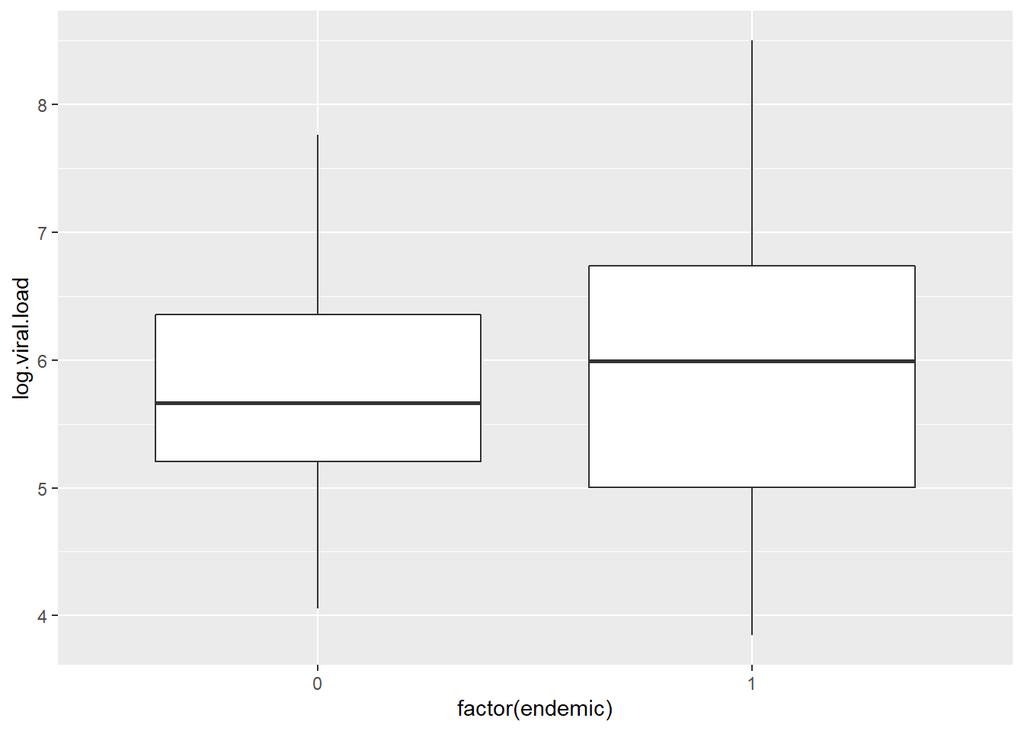

```r
fishDat %>% ggplot(aes(x=factor(endemic), y=log.viral.load)) +
  geom_boxplot()
```

```r
fishDat %>% group_by(endemic) %>%
  summarize(
    mean = mean(log.viral.load, na.rm=TRUE),
    sd = sd(log.viral.load, na.rm=TRUE)
  )
```

```
## # A tibble: 2 x 3
##   endemic  mean    sd
##     <dbl> <dbl> <dbl>
## 1       0  5.84 0.958
## 2       1  5.94 1.15
```

```r
t.test(
  # viral loads for fish exposed to L:
  x = fishDat$log.viral.load[fishDat$endemic == 0],
  # viral loads for fish exposed to U or M:
  y = fishDat$log.viral.load[fishDat$endemic == 1]
  )
```

```
##
##  Welch Two Sample t-test
##
## data:  fishDat$log.viral.load[fishDat$endemic == 0] and fishDat$log.viral.load[fishDat$endemic == 1]
## t = -0.54701, df = 120.05, p-value = 0.5854
## alternative hypothesis: true difference in means is not equal to 0
## 95 percent confidence interval:
##  -0.4405514  0.2498183
## sample estimates:
## mean of x mean of y
##  5.840214  5.935580
```

*Given what you know about tests of independence and what you know about P-values, what should you conclude about the null hypothesis (one sentence)? What does this lead you to conclude about the association between the endemic/exotic strain variable and the log viral load variable (one sentence)?* I can conclude that the we can fail to reject the null hypothesis, therefore we cannot conclude there is or there is not association between the endemic/exotic strain variable and the log viral load variables.

# Exercise 3

The following chunk performs an analysis of variance (ANOVA) test of independence between the multilevel categorical variable `strain` and the numerical variable `log.viral.load`. This test works by asking whether the whole-sample or between-strain variance is significantly greater than the within-strain variance. It helps us to avoid the quadratically increasing multiple-testing problem that arises when we analyze multilevel categorical variables such as strain, if the other variable is numerical.

```r
anova(lm(formula = log.viral.load ~ strain, data = fishDat))
```

```
## Analysis of Variance Table
##
## Response: log.viral.load
##            Df  Sum Sq Mean Sq F value Pr(>F)
## strain      2   4.856  2.4279  2.0937 0.1268
## Residuals 152 176.261  1.1596
```

The P-value for this test of independence is 0.1268.

*Given what you know about tests of independence and what you know about P-values, what should you conclude about the null hypothesis (one sentence)? What does this lead you to conclude about the association between the strain variable and the log viral load variable (one sentence)?* I can conclude that we can fail to reject this null hypothesis, therefore we cannot conclude whether there is or there is not an association between the strain variable and the log viral load variable.

# Extra credit

The following chunk performs a simple regression analysis to evaluate the relationship between log exposure dose and log viral load.

```r
loadMod1 <- lm(
  data = fishDat,
  formula = log.viral.load ~ dose
  )
summary(loadMod1)
```

[output not shown]

We can use a T test of independence based on the effect size of exposure dose, $\beta$. The null hypothesis is
$$H_0:\beta=0$$
The P-value for this T test for the above regression analysis is 0.082.